# Capstone Data Analysis

Trenton Denton

2022-03-12

## Netflix: Data Exploration

This is my capstone data analysis project. Written in R using RStudio Desktop https://www.rstudio.com/ If you would like to perform your own analysis on this data the link to this dataset is https://www.kaggle.com/shivamb/netflix-shows. This study was performed on 03/12/2022.

#### Introduction:

I will analyze the data from the Netflix streaming service. Netflix, Inc. is a media services provider and production company that was founded in 1997 in Scotts Valley, California. The company has since expanded with international offices around the world. The company is primarily known for it’s subscription-based streaming services which allows people to stream a large library of Movies and TV Shows.

This dataset consists of Movies and TV Shows available on the Netflix Streaming service as of 2022 (updated). The dataset is collected from Flixable which is a third-party Netflix search engine.

#### Key Objectives:

- Are there more TV Shows or Movies Released Yearly?
- What is the overall percentage of Movies vs TV Shows?
- What are the most common genre of films (both TV Shows and Movies)?
- What is the most common rating of the TV Shows / Movies?
- What country creates the most Films?

This is an R Markdown document http://rmarkdown.rstudio.com. If you are unfamiliar with R you must install the following libraries first using install.packages(“packagename”) prior to adding them to your library.

```r
library(tidyverse)
library(readr)
library(ggplot2)
library(tibble)
library(lubridate)
```

#### Adding Data:

```r
#Load Data
netflix_info <- read_csv("C:/Users/trent/Desktop/Capstone/netflixdata/netflix_titles.csv", show_col_types = 'FALSE')

#Preview Data
glimpse(netflix_info)
```

```
## Rows: 8,807
## Columns: 12
## $ show_id      <chr> "s1", "s2", "s3", "s4", "s5", "s6", "s7", "s8", "s9", "s1~
## $ type         <chr> "Movie", "TV Show", "TV Show", "TV Show", "TV Show", "TV ~
## $ title        <chr> "Dick Johnson Is Dead", "Blood & Water", "Ganglands", "Ja~
## $ director     <chr> "Kirsten Johnson", NA, "Julien Leclercq", NA, NA, "Mike F~
## $ cast         <chr> NA, "Ama Qamata, Khosi Ngema, Gail Mabalane, Thabang Mola~
## $ country      <chr> "United States", "South Africa", NA, NA, "India", NA, NA,~
## $ date_added   <chr> "September 25, 2021", "September 24, 2021", "September 24~
## $ release_year <dbl> 2020, 2021, 2021, 2021, 2021, 2021, 2021, 1993, 2021, 202~
## $ rating       <chr> "PG-13", "TV-MA", "TV-MA", "TV-MA", "TV-MA", "TV-MA", "PG~
## $ duration     <chr> "90 min", "2 Seasons", "1 Season", "1 Season", "2 Seasons~
## $ listed_in    <chr> "Documentaries", "International TV Shows, TV Dramas, TV M~
## $ description  <chr> "As her father nears the end of his life, filmmaker Kirst~
```

```r
summary(netflix_info)
```

```
##    show_id              type              title             director
##  Length:8807        Length:8807        Length:8807        Length:8807
##  Class :character   Class :character   Class :character   Class :character
##  Mode  :character   Mode  :character   Mode  :character   Mode  :character
##
##
##
##      cast             country           date_added         release_year
##  Length:8807        Length:8807        Length:8807        Min.   :1925
##  Class :character   Class :character   Class :character   1st Qu.:2013
##  Mode  :character   Mode  :character   Mode  :character   Median :2017
##                                                           Mean   :2014
##                                                           3rd Qu.:2019
##                                                           Max.   :2021
##     rating            duration          listed_in         description
##  Length:8807        Length:8807        Length:8807        Length:8807
##  Class :character   Class :character   Class :character   Class :character
##  Mode  :character   Mode  :character   Mode  :character   Mode  :character
##
##
##
```

#### Seperating Film Types:

```r
#Separate into Three Category Columns & Keep the First
netflix_info <- netflix_info %>% separate(listed_in, c("Category1", "Category2", "Category3"), sep=",")
netflix_info <- netflix_info %>% select(c(-"Category2", -"Category3"))

#Separate Date Added (into Date & Year)
netflix_info <- netflix_info %>% separate(date_added, c("date_added", "year_added"), sep=",")
```

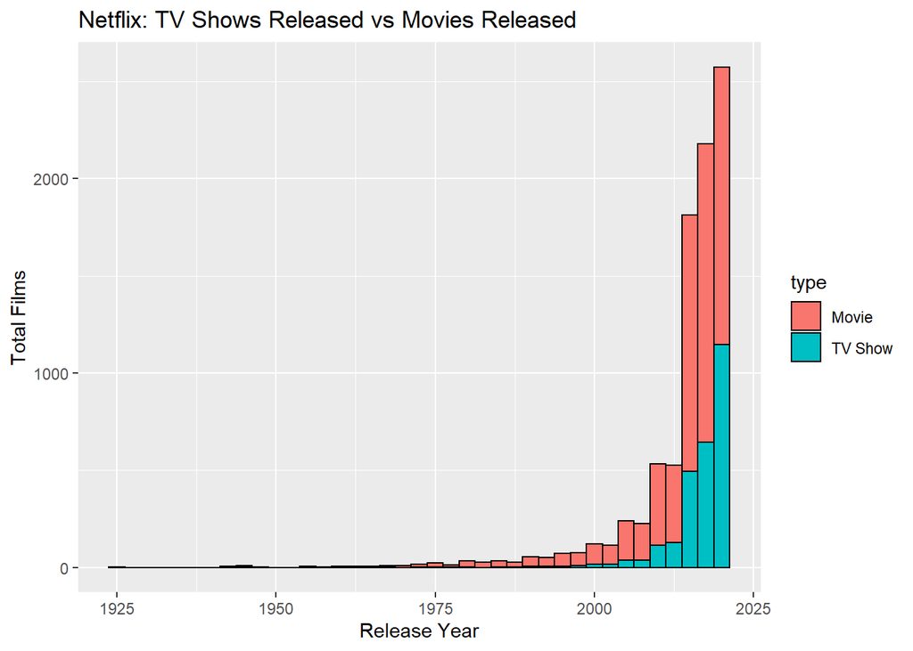

```r
#GG Plot For Films Released By Year (Separated by Type: Movie / TV Show)
ggplot(netflix_info, mapping= aes(x=release_year, fill=type)) +
  geom_histogram(color = "black", binwidth=2.5) +
  labs(title="Netflix: TV Shows Released vs Movies Released", x="Release Year", y="Total Films")
```

```r
#Updating Year Added to Numeric Value
netflix_info$year_added <- as.numeric(netflix_info$year_added)
```

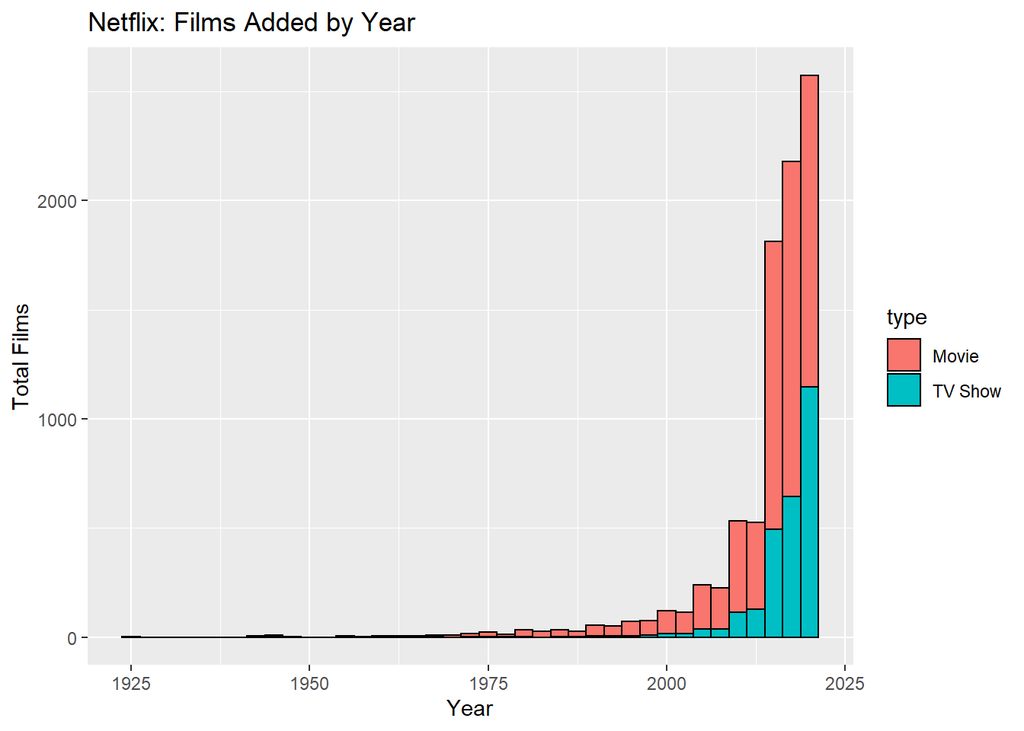

```r
#Updating GG Plot
ggplot(netflix_info, mapping= aes(x=release_year, fill=type)) +
  geom_histogram(color = "black", binwidth=2.5) +
  labs(title="Netflix: Films Added by Year", x="Year", y="Total Films")
```

Are there more TV Shows or Movies Released Yearly? The dataset indicates more Movies are released yearly!

```r
#Creating New Data Frame for Movie Genre's
netflix_types <- netflix_info %>% group_by(type) %>% count() %>% ungroup() %>%
  mutate(perc = `n` / sum(`n`)) %>%
  arrange(perc) %>%
  mutate(labels = scales::percent(perc))
```

```r
head(netflix_types)
```

```
## # A tibble: 2 x 4
##   type        n  perc labels
##   <chr>   <int> <dbl> <chr>
## 1 TV Show  2676 0.304 30%
## 2 Movie    6131 0.696 70%
```

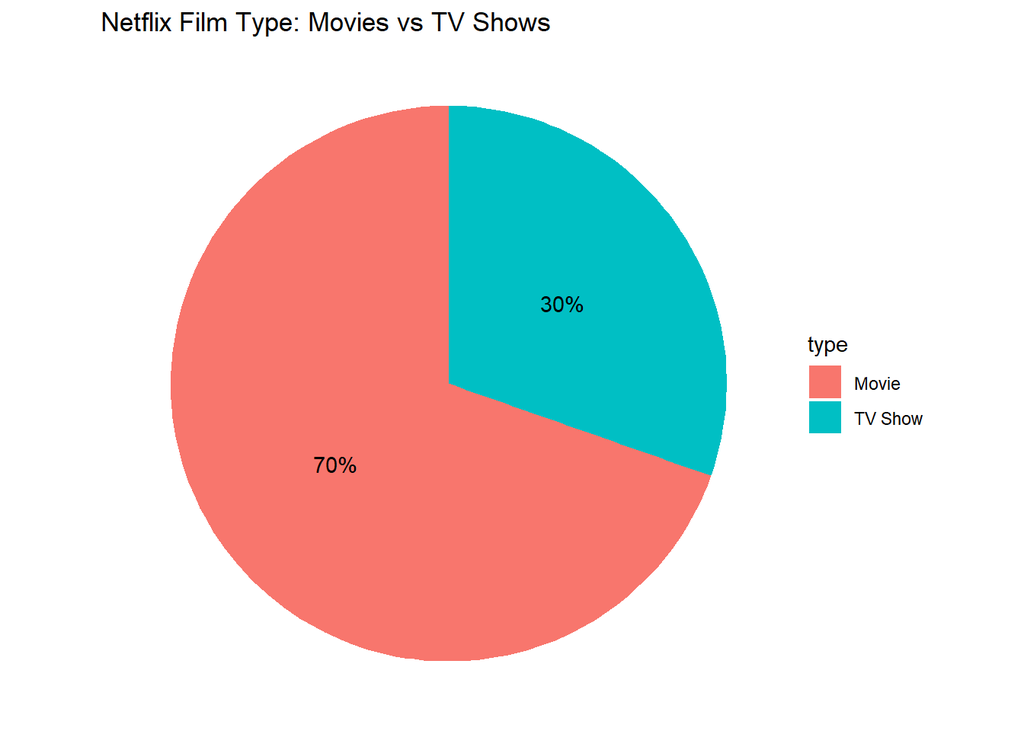

```r
#GG Plot for Pie Chart % Movie vs. TV Show
ggplot(netflix_types, aes(x="", y = perc, fill= type)) +
  geom_col()+
  geom_text(aes(label = labels), position = position_stack(vjust = 0.5)) +
  coord_polar(theta = "y") +
  labs(title="Netflix Film Type: Movies vs TV Shows") +
  theme_void()
```

What is the overall percentage of Movies vs TV Shows? The dataset indicates 70% are Movies and 30% are TV Shows.

#### Top 10 Genres

```r
#Netflix Films by Genre's
genre1 <- netflix_info %>% group_by(Category1) %>% count

#Creating Top 9 Genres + Combining "Others": Into a Top 10 Genres DataFrame
top9_genres <- filter(genre1, n > 300) %>% arrange(desc(n))
other_genres <- filter(genre1, n < 300)

other_genres <- data.frame(Category1 = c("Others*"), n=c(sum(other_genres$n)))
top10_genres <- rbind(top9_genres, other_genres)
```

```r
head(top10_genres)
```

```
## # A tibble: 6 x 2
## # Groups:   Category1 [6]
##   Category1                    n
##   <chr>                    <int>
## 1 Dramas                    1600
## 2 Comedies                  1210
## 3 Action & Adventure         859
## 4 Documentaries              829
## 5 International TV Shows     774
## 6 Children & Family Movies   605
```

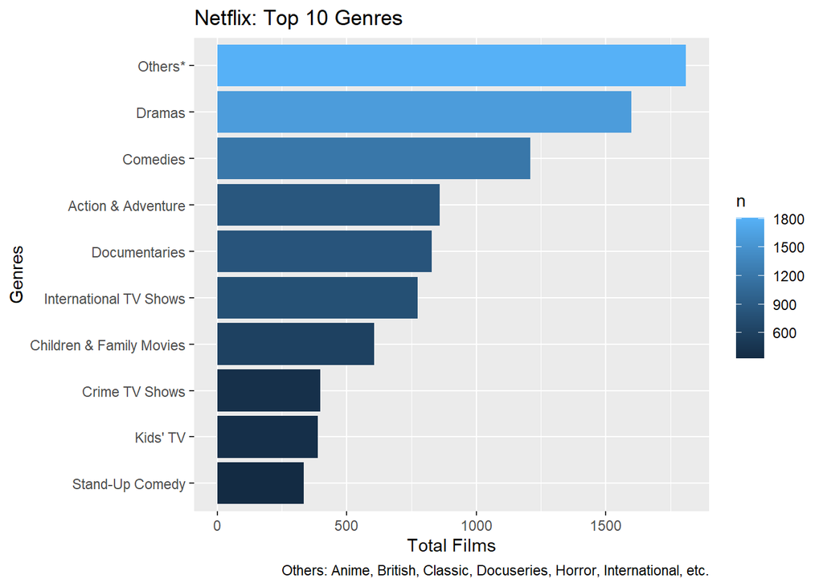

```r
#GGPlot For Top 10 Genres
ggplot(data = top10_genres, aes(x = reorder(Category1, n), y = n, fill=n)) +
  geom_bar(stat = "identity") +
  coord_flip()+
  labs(title = "Netflix: Top 10 Genres", x = "Genres", y = "Total Films", caption = "Others: Anime, British, Classic, Docuseries, Horror, International, etc.")
```

What are the most common genre of films (both TV Shows and Movies)? The dataset indicates Dramas & Comedies are the most common.

#### Top 10 Ratings

```r
#Netflix Films by Ratings
ratings <- netflix_info %>% group_by(rating) %>% count()

#Adding Top 9 Ratings + Combining "Others": Into a Top 10 Ratings
top9_ratings <- filter(ratings, n > 200) %>% arrange(desc(n))
other_ratings <- filter(ratings, n < 200)

other_ratings <- drop_na(other_ratings)
other_ratings <- data.frame(rating = c("Others*"), n = c(sum(other_ratings$n)))
top10_ratings <- rbind(top9_ratings, other_ratings)
```

```r
head(top10_ratings)
```

```
## # A tibble: 6 x 2
## # Groups:   rating [6]
##   rating     n
##   <chr>  <int>
## 1 TV-MA   3207
## 2 TV-14   2160
## 3 TV-PG    863
## 4 R        799
## 5 PG-13    490
## 6 TV-Y7    334
```

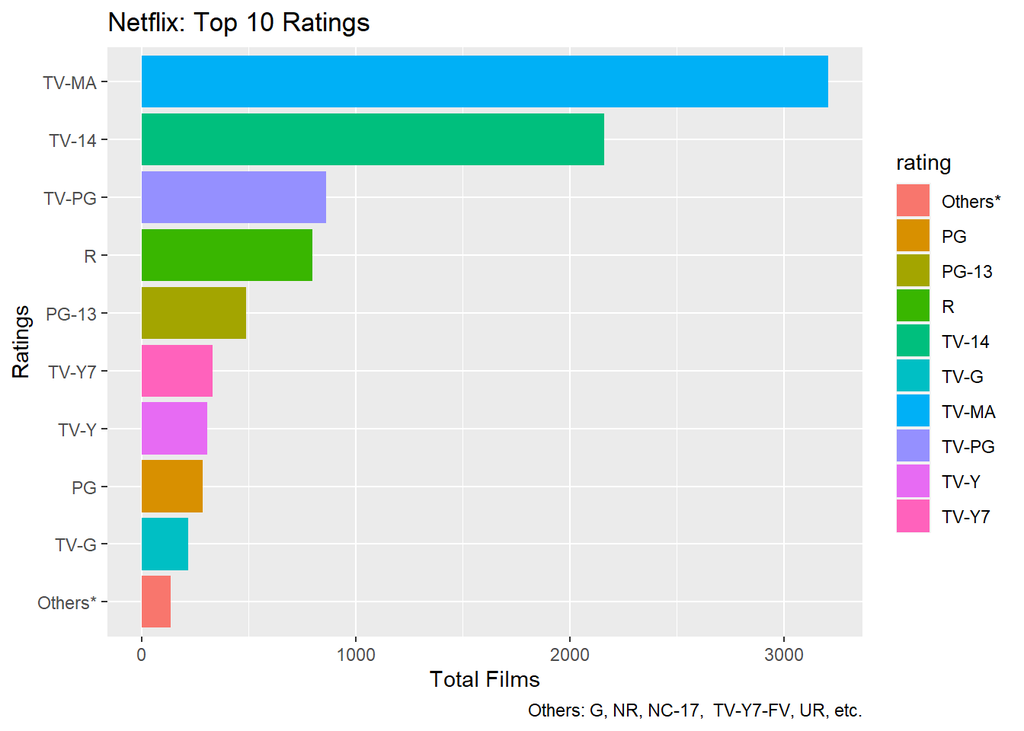

```r
#GGPlot For Top 10 Ratings
#GGPlot For Top 10 Ratings
ggplot(data = top10_ratings, aes(x = reorder(rating, n), y=n, fill=rating)) +
  geom_bar(stat = "identity") +
  coord_flip() +
  labs(title= "Netflix: Top 10 Ratings", x="Ratings", y="Total Films", caption = "Others: G, NR, NC-17,  TV-Y7-FV, UR, etc.")
```

What is the most common rating of the TV Shows / Movies? The dataset indicates that TV-MA and TV-14 are the two most common ratings.

#### Films by Country

```r
#Netflix Films By Country
countries <- netflix_info %>%
  select(country, type, title, year_added)
sum(is.na(countries$country))/nrow(countries)
```

```
## [1] 0.09435676
```

```r
countries <- countries %>%
  filter(!is.na(country))

#Split Countries into Single Country
max(str_count(countries$country, ','))
```

```
## [1] 11
```

```r
countr <- countries %>%
  separate(country, into =c('a', 'b', 'c', 'd', 'e', 'f', 'g', 'h', 'i', 'j', 'k', 'l')
           ,", ", convert = TRUE)
countr <-countr[,1:12]
countr_list <- countr %>%
  unlist()
countr_tibble <- tibble(
  country_name=countr_list
)

#Create Country Tibble
ctr <- countr_tibble %>%
  group_by(country_name) %>%
  count() %>%
  filter(!is.na(country_name))
```

```r
head(ctr)
```

```
## # A tibble: 6 x 2
## # Groups:   country_name [6]
##   country_name      n
##   <chr>         <int>
## 1 ""                2
## 2 "Afghanistan"     1
## 3 "Albania"         1
## 4 "Algeria"         3
## 5 "Angola"          1
## 6 "Argentina"      91
```

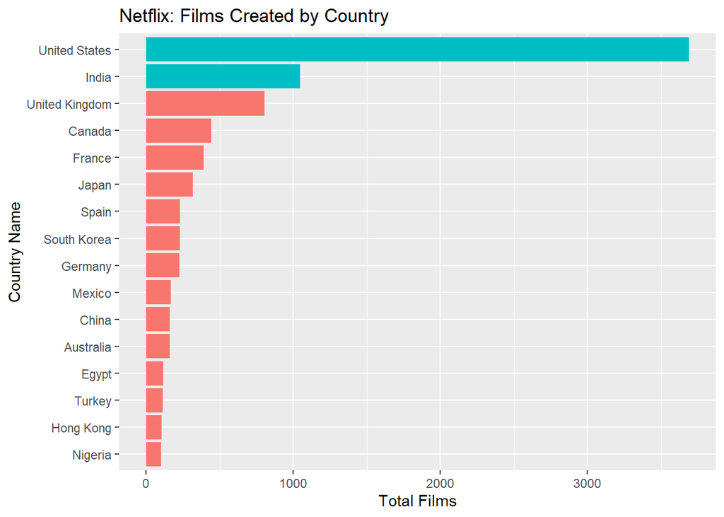

```r
#GGPlot for Films by Country
ctr %>%
  filter(n > 100 && country_name != '') %>%
  ggplot(aes(n, reorder(country_name, FUN=median, n), fill = n > 1000)) +
  geom_bar(stat='identity', show.legend = F) +
  labs(title="Netflix: Films Created by Country", x="Total Films", y="Country Name")
```

What country creates the most Films? The dataset indicates that the United States creates the most films.

#### Final Notes:

As you may have noticed throughout this R Markdown Notebook: Netflix is popular around the world. The COVID-19 pandemic has helped to increase it’s popularity due to people being in their homes more (quarantines, travel restrictions, etc.)

I hope that you enjoyed my analysis! If you have any questions feel free to reach out.

Trenton Denton